# Composição/diversidade de comunidades de abelhas em função da estrutura da paisagem

Estrutura da Paisagem (proporção de habitat natural x heterogeneidade) e Composição de Espécies

Cinthia Soares Noves

22 de outubro de 2025

# 1 Introdução

## 1.1 Contexto

*Pergunta: Como a composição e a diversidade de abelhas respondem à estrutura da paisagem, considerando a proporção de habitat natural e a heterogeneidade de usos e coberturas do solo?*

**H1:** A diversidade e a composição de abelhas estão mais fortemente associadas à proporção de habitat natural, de modo que áreas com maior cobertura natural apresentam maior diversidade de espécies.

**H2:** Mosaicos de diferentes classes de uso e cobertura do solo oferecem recursos complementares que sustentam maior diversidade e mantêm comunidades distintas, tornando a heterogeneidade da paisagem um preditor mais importante.

**H0:** Não há associação significativa entre a proporção de habitat natural e a heterogeneidade da paisagem e os padrões de diversidade e composição de abelhas neste estudo. As diferenças observadas podem ser atribuídas ao acaso ou a fatores não identificados na presente abordagem.

**Delineamento amostral:** - **6 locais** com diferentes contextos (3 bordas urbanas + 3 zonas rurais) - **9 pontos** por local - **Total: 54 pontos amostrais**

## 1.2 Objetivos

Os principais objetivos desta análise são:

1. **Diversidade Alfa**: Avaliar como a propoção de habitat natural e a heterogeneidade da paisagem afetam a riqueza de espécies (usando GLMM para controlar pseudorreplicação)
2. **Composição Beta**: Testar se áreas de borda urbana diferem de zonas rurais em termos de composição de espécies
3. **Análises Multivariadas**: Identificar padrões espaciais e espécies indicadoras

## 1.3 Métodos Estatísticos

- **GLMM (Modelo Misto)**: Riqueza por ponto (n=54) com Local como efeito aleatório
- **NMDS**: Ordenação da composição de espécies
- **PERMANOVA**: Teste de efeito de variáveis ambientais na composição
- **ANOSIM**: Diferenças entre grupos (contextos e locais)
- **IndVal e SIMPER**: Espécies indicadoras e contribuintes

# 2 Configuração Inicial

## 2.1 Carregar Pacotes

```r
library(tidyverse)
library(readxl)
library(vegan)
library(lme4)      # Para modelos mistos
library(MuMIn)
library(indicspecies)
library(ggplot2)
library(viridis)
library(gridExtra)
library(car)
```

## 2.2 Importar e Limpar Dados

```r
# Importar dados
dados <- read_excel("../dados/Cap2.xlsx", sheet = "Doc_Cinthia")

# Limpeza de dados
dados <- dados %>%
  filter(
    Especie != "Vespa",
    Especie != "NA",
    !is.na(Especie),
    Especie != "Crabronidae sp.",
    Especie != "Xylocopa grisescens"
  ) %>%
  mutate(
    # Corrigir nomes com espaços
    Especie = str_trim(Especie),

    # Calcular total da paisagem
    total_paisagem = Area_Natural + Area_Urbana + Pastagem + Mosaico_Usos +
      Areas_nao_veg. + Mineracao + Lagos + Lavouras_Temp.,

    # Criar contexto espacial
    contexto = case_when(
      Local %in% c("TM_", "IF_", "MARM_") ~ "Borda_Urbana",
      Local %in% c("SG_", "MV_", "CUR_") ~ "Zona_Rural",
      TRUE ~ NA_character_
    ),

    # Criar ID único para cada ponto
    ID_ponto = paste(Local, Ponto, sep = "_")
  )

# Resumo dos dados
cat("📊 DADOS CARREGADOS:\n")
```

```
## 📊 DADOS CARREGADOS:
```

```r
cat("  - Total de registros:", nrow(dados), "\n")
```

```
##   - Total de registros: 1269
```

```r
cat("  - Número de espécies:", n_distinct(dados$Especie), "\n")
```

```
##   - Número de espécies: 41
```

```r
cat("  - Locais amostrados:", n_distinct(dados$Local), "\n")
```

```
##   - Locais amostrados: 6
```

```r
cat("  - Pontos únicos:", n_distinct(dados$ID_ponto), "\n")
```

```
##   - Pontos únicos: 54
```

# 3 Diversidade Alfa (GLMM - 54 pontos)

## 3.1 Calcular Riqueza por Ponto

```r
riqueza_por_ponto <- dados %>%
  group_by(ID_ponto) %>%
  summarise(
    Local = first(Local),
    contexto = first(contexto),
    prop_hab_natural = first(Area_Natural) / first(total_paisagem),
    heterogeneidade = vegan::diversity(
      c(first(Area_Urbana), first(Pastagem), first(Mosaico_Usos),
        first(Areas_nao_veg.), first(Mineracao), first(Lagos),
        first(Lavouras_Temp.)),
      index = "shannon"
    ),
    riqueza = n_distinct(Especie),
    abundancia = n(),
    .groups = "drop"
  )

cat("📊 Resumo da riqueza por ponto:\n")
```

```
## 📊 Resumo da riqueza por ponto:
```

```r
print(summary(riqueza_por_ponto))
```

```
##    ID_ponto            Local             contexto         prop_hab_natural
##  Length:54          Length:54          Length:54          Min.   :0.4784
##  Class :character   Class :character   Class :character   1st Qu.:0.6122
##  Mode  :character   Mode  :character   Mode  :character   Median :0.6414
##                                                           Mean   :0.6997
##                                                           3rd Qu.:0.8817
##                                                           Max.   :0.9433
##  heterogeneidade     riqueza         abundancia
##  Min.   :0.4694   Min.   : 1.000   Min.   : 4.0
##  1st Qu.:0.6846   1st Qu.: 4.000   1st Qu.:12.0
##  Median :1.0259   Median : 5.500   Median :21.5
##  Mean   :0.9481   Mean   : 6.167   Mean   :23.5
##  3rd Qu.:1.1541   3rd Qu.: 8.000   3rd Qu.:28.0
##  Max.   :1.3284   Max.   :16.000   Max.   :70.0
```

```r
cat("\n📈 Estatísticas descritivas:\n")
```

```
##
## 📈 Estatísticas descritivas:
```

```r
cat("  - Riqueza média:", round(mean(riqueza_por_ponto$riqueza), 2), "±",
    round(sd(riqueza_por_ponto$riqueza), 2), "\n")
```

```
##   - Riqueza média: 6.17 ± 3.12
```

```r
cat("  - Riqueza mínima:", min(riqueza_por_ponto$riqueza), "\n")
```

```
##   - Riqueza mínima: 1
```

```r
cat("  - Riqueza máxima:", max(riqueza_por_ponto$riqueza), "\n")
```

```
##   - Riqueza máxima: 16
```

## 3.2 Modelos Lineares Generalizados Mistos (GLMM)

### 3.2.1 Seleção de Modelos

```r
cat("\n=== AJUSTANDO GLMMs ===\n")
```

```
##
## === AJUSTANDO GLMMs ===
```

```r
cat("Local é incluído como efeito aleatório para controlar pseudorreplicação\n\n")
```

```
## Local é incluído como efeito aleatório para controlar pseudorreplicação
```

```r
# Modelos candidatos
m1 <- glmer(riqueza ~ prop_hab_natural + (1|Local),
            data = riqueza_por_ponto,
            family = poisson,
            control = glmerControl(optimizer = "bobyqa"))

m2 <- glmer(riqueza ~ heterogeneidade + (1|Local),
            data = riqueza_por_ponto,
            family = poisson,
            control = glmerControl(optimizer = "bobyqa"))

m3 <- glmer(riqueza ~ prop_hab_natural + heterogeneidade + (1|Local),
            data = riqueza_por_ponto,
            family = poisson,
            control = glmerControl(optimizer = "bobyqa"))

m4 <- glmer(riqueza ~ prop_hab_natural * heterogeneidade + (1|Local),
            data = riqueza_por_ponto,
            family = poisson,
            control = glmerControl(optimizer = "bobyqa"))

m5 <- glmer(riqueza ~ prop_hab_natural + heterogeneidade + contexto + (1|Local),
            data = riqueza_por_ponto,
            family = poisson,
            control = glmerControl(optimizer = "bobyqa"))

# Comparar modelos
tabela_modelos <- model.sel(m1, m2, m3, m4, m5)
print(tabela_modelos)
```

```
## Model selection table
##      (Int) prp_hab_ntr     htr htr:prp_hab_ntr cnt df   logLik  AICc delta
## m4 -0.5147      4.1520  2.4260          -4.332      5 -126.398 264.0  0.00
## m1  1.2240      0.8050                              3 -129.610 265.7  1.65
## m2  2.0650             -0.2924                      3 -130.050 266.6  2.53
## m3  1.5100      0.8643 -0.3447                      4 -129.107 267.0  2.98
## m5  1.8230      0.1168 -0.3034                   +  5 -128.206 267.7  3.61
##    weight
## m4  0.474
## m1  0.207
## m2  0.134
## m3  0.107
## m5  0.078
## Models ranked by AICc(x)
## Random terms (all models):
##   1 | Local
```

### 3.2.2 Melhor Modelo

```r
# Extrair melhor modelo
melhor_modelo <- get.models(tabela_modelos, subset = 1)[[1]]

cat("\n📊 MELHOR MODELO (menor AICc):\n")
```

```
##
## 📊 MELHOR MODELO (menor AICc):
```

```r
cat("AICc:", round(AICc(melhor_modelo), 2), "\n")
```

```
## AICc: 264.05
```

```r
cat("ΔAICc:", round(tabela_modelos$delta[1], 2), "\n\n")
```

```
## ΔAICc: 0
```

```r
# Mostrar coeficientes
cat("Efeitos fixos:\n")
```

```
## Efeitos fixos:
```

```r
print(summary(melhor_modelo)$coefficients)
```

```
##                                    Estimate Std. Error    z value     Pr(>|z|)
## (Intercept)                      -0.5147305  0.7599840 -0.6772913 0.4982211582
## prop_hab_natural                  4.1515650  1.1510980  3.6066129 0.0003102199
## heterogeneidade                   2.4257171  0.9763438  2.4844906 0.0129736937
## prop_hab_natural:heterogeneidade -4.3317583  1.4858185 -2.9154019 0.0035523073
```

```r
cat("\n\nVariância do efeito aleatório (Local):\n")
```

```
##
##
## Variância do efeito aleatório (Local):
```

```r
print(VarCorr(melhor_modelo))
```

```
##  Groups Name        Std.Dev.
##  Local  (Intercept) 0.045768
```

```r
# Testar overdispersion
deviance_residual <- sum(residuals(melhor_modelo, type = "deviance")^2)
df_residual <- df.residual(melhor_modelo)
dispersion <- deviance_residual / df_residual

cat("\n🔍 Teste de Overdispersion:", round(dispersion, 3), "\n")
```

```
##
## 🔍 Teste de Overdispersion: 1.214
```

```r
if(dispersion > 1.5) {
  cat("⚠️ Overdispersion detectada (>1.5). Considere usar família Negative Binomial.\n")
} else {
  cat("✓ Sem problemas de overdispersion.\n")
}
```

```
## ✓ Sem problemas de overdispersion.
```

```r
# VIF (verificar colinearidade - só para modelos com 2+ preditores fixos)
if(length(fixef(melhor_modelo)) > 2) {
  cat("\n🔍 VIF (Colinearidade dos preditores):\n")
  cat("VIF > 3 indica colinearidade problemática\n\n")
  print(vif(melhor_modelo))
}
```

```
##
## 🔍 VIF (Colinearidade dos preditores):
## VIF > 3 indica colinearidade problemática
##
##                 prop_hab_natural                  heterogeneidade
##                         10.93500                         22.35782
## prop_hab_natural:heterogeneidade
##                         31.06350
```

**Interpretação:** O modelo misto (GLMM) usa os 54 pontos mas controla a não-independência dos pontos dentro de cada local através do efeito aleatório `(1|Local)`. Isso é estatisticamente mais robusto do que usar apenas os 6 locais.

# 4 Análises Multivariadas (54 pontos)

## 4.1 Preparar Matrizes

```r
# Matriz de comunidade: pontos × espécies
matriz_comunidade_pontos <- dados %>%
  group_by(ID_ponto, Especie) %>%
  summarise(abundancia = n(), .groups = "drop") %>%
  pivot_wider(names_from = Especie, values_from = abundancia, values_fill = 0) %>%
  column_to_rownames("ID_ponto")

cat("📐 Dimensões da matriz:", dim(matriz_comunidade_pontos), "\n")
```

```
## 📐 Dimensões da matriz: 54 41
```

```r
cat("   (", nrow(matriz_comunidade_pontos), " pontos × ",
    ncol(matriz_comunidade_pontos), " espécies)\n\n", sep = "")
```

```
##    (54 pontos × 41 espécies)
```

```r
# Variáveis ambientais por ponto
variaveis_pontos <- dados %>%
  group_by(ID_ponto) %>%
  summarise(
    Local = first(Local),
    contexto = first(contexto),
    prop_hab_natural = first(Area_Natural) / first(total_paisagem),
    heterogeneidade = vegan::diversity(
      c(first(Area_Urbana), first(Pastagem), first(Mosaico_Usos),
        first(Areas_nao_veg.), first(Mineracao), first(Lagos),
        first(Lavouras_Temp.)),
      index = "shannon"
    ),
    .groups = "drop"
  ) %>%
  column_to_rownames("ID_ponto")

# Verificar alinhamento
cat("✓ Alinhamento de matrizes:",
    all(rownames(matriz_comunidade_pontos) == rownames(variaveis_pontos)), "\n")
```

```
## ✓ Alinhamento de matrizes: TRUE
```

## 4.2 NMDS (Ordenação)

```r
cat("\n=== CALCULANDO NMDS ===\n")
```

```
##
## === CALCULANDO NMDS ===
```

```r
set.seed(123)
nmds_pontos <- metaMDS(matriz_comunidade_pontos,
                       distance = "bray",
                       k = 2,
                       trymax = 100,
                       trace = FALSE)

cat("📊 Stress do NMDS (k=2):", round(nmds_pontos$stress, 4), "\n\n")
```

```
## 📊 Stress do NMDS (k=2): 0.2256
```

```r
cat("Interpretação do Stress:\n")
```

```
## Interpretação do Stress:
```

```r
cat("  < 0.05: Excelente\n")
```

```
##   < 0.05: Excelente
```

```r
cat("  0.05-0.10: Ótimo\n")
```

```
##   0.05-0.10: Ótimo
```

```r
cat("  0.10-0.20: Bom\n")
```

```
##   0.10-0.20: Bom
```

```r
cat("  > 0.20: Regular/Ruim\n")
```

```
##   > 0.20: Regular/Ruim
```

```r
# Se stress alto, tentar k=3
if(nmds_pontos$stress > 0.20) {
  cat("\n⚠️ Stress alto! Tentando k=3...\n")
  nmds_pontos <- metaMDS(matriz_comunidade_pontos,
                         distance = "bray",
                         k = 3,
                         trymax = 100,
                         trace = FALSE)
  cat("✓ Novo stress (k=3):", round(nmds_pontos$stress, 4), "\n")
}
```

```
##
## ⚠️ Stress alto! Tentando k=3...
## ✓ Novo stress (k=3): 0.1627
```

## 4.3 PERMANOVA

```r
cat("\n\n=== PERMANOVA ===\n")
```

```
##
##
## === PERMANOVA ===
```

```r
# Modelo 1: Variáveis ambientais contínuas
perm1 <- adonis2(matriz_comunidade_pontos ~ prop_hab_natural + heterogeneidade,
                 data = variaveis_pontos,
                 permutations = 999,
                 method = "bray")

# Modelo 2: Adicionando contexto
perm2 <- adonis2(matriz_comunidade_pontos ~ prop_hab_natural + heterogeneidade + contexto,
                 data = variaveis_pontos,
                 permutations = 999,
                 method = "bray")

# Modelo 3: Com interação
perm3 <- adonis2(matriz_comunidade_pontos ~ (prop_hab_natural + heterogeneidade) * contexto,
                 data = variaveis_pontos,
                 permutations = 999,
                 method = "bray")

# Modelo 4: Bloqueado por Local (controla pseudorreplicação)
perm_blocked <- adonis2(matriz_comunidade_pontos ~ prop_hab_natural + heterogeneidade,
                        data = variaveis_pontos,
                        permutations = 999,
                        method = "bray",
                        strata = variaveis_pontos$Local)

cat("\n--- PERMANOVA: Habitat + Heterogeneidade ---\n")
```

```
##
## --- PERMANOVA: Habitat + Heterogeneidade ---
```

```r
print(perm1)
```

```
## Permutation test for adonis under reduced model
## Permutation: free
## Number of permutations: 999
##
## adonis2(formula = matriz_comunidade_pontos ~ prop_hab_natural + heterogeneidade, data = variaveis_pontos, permutations = 999, method = "bray")
##          Df SumOfSqs      R2      F Pr(>F)
## Model     2   1.4383 0.14952 4.4831  0.001 ***
## Residual 51   8.1813 0.85048
## Total    53   9.6196 1.00000
## ---
## Signif. codes:  0 '***' 0.001 '**' 0.01 '*' 0.05 '.' 0.1 ' ' 1
```

```r
cat("\n--- PERMANOVA: + Contexto ---\n")
```

```
##
## --- PERMANOVA: + Contexto ---
```

```r
print(perm2)
```

```
## Permutation test for adonis under reduced model
## Permutation: free
## Number of permutations: 999
##
## adonis2(formula = matriz_comunidade_pontos ~ prop_hab_natural + heterogeneidade + contexto, data = variaveis_pontos, permutations = 999, method = "bray")
##          Df SumOfSqs    R2      F Pr(>F)
## Model     3   1.7989 0.187 3.8336  0.001 ***
## Residual 50   7.8207 0.813
## Total    53   9.6196 1.000
## ---
## Signif. codes:  0 '***' 0.001 '**' 0.01 '*' 0.05 '.' 0.1 ' ' 1
```

```r
cat("\n--- PERMANOVA: Com Interação ---\n")
```

```
##
## --- PERMANOVA: Com Interação ---
```

```r
print(perm3)
```

```
## Permutation test for adonis under reduced model
## Permutation: free
## Number of permutations: 999
##
## adonis2(formula = matriz_comunidade_pontos ~ (prop_hab_natural + heterogeneidade) * contexto, data = variaveis_pontos, permutations = 999, method = "bray")
##          Df SumOfSqs      R2      F Pr(>F)
## Model     5   2.6669 0.27724 3.6824  0.001 ***
## Residual 48   6.9527 0.72276
## Total    53   9.6196 1.00000
## ---
## Signif. codes:  0 '***' 0.001 '**' 0.01 '*' 0.05 '.' 0.1 ' ' 1
```

```r
cat("\n--- PERMANOVA BLOQUEADA por Local (RECOMENDADO) ---\n")
```

```
##
## --- PERMANOVA BLOQUEADA por Local (RECOMENDADO) ---
```

```r
print(perm_blocked)
```

```
## Permutation test for adonis under reduced model
## Blocks:  strata
## Permutation: free
## Number of permutations: 999
##
## adonis2(formula = matriz_comunidade_pontos ~ prop_hab_natural + heterogeneidade, data = variaveis_pontos, permutations = 999, method = "bray", strata = variaveis_pontos$Local)
##          Df SumOfSqs      R2      F Pr(>F)
## Model     2   1.4383 0.14952 4.4831      1
## Residual 51   8.1813 0.85048
## Total    53   9.6196 1.00000
```

**Interpretação:** A PERMANOVA testa se as variáveis ambientais explicam diferenças na composição de espécies. O R² indica a proporção da variância explicada. O modelo bloqueado controla a pseudorreplicação dos pontos dentro de cada local.

## 4.4 ANOSIM

```r
cat("\n\n=== ANOSIM ===\n")
```

```
##
##
## === ANOSIM ===
```

```r
# Calcular matriz de distância
dist_bray <- vegdist(matriz_comunidade_pontos, method = "bray")

# 1. Por CONTEXTO
anosim_contexto <- anosim(dist_bray, variaveis_pontos$contexto, permutations = 999)

# 2. Por LOCAL
anosim_local <- anosim(dist_bray, variaveis_pontos$Local, permutations = 999)

# 3. Por categoria de HABITAT
tercis <- quantile(variaveis_pontos$prop_hab_natural, probs = c(0.33, 0.67))
categoria_habitat <- cut(variaveis_pontos$prop_hab_natural,
                         breaks = c(-Inf, tercis[1], tercis[2], Inf),
                         labels = c("Baixo", "Medio", "Alto"))
anosim_habitat <- anosim(dist_bray, categoria_habitat, permutations = 999)

cat("--- ANOSIM: Borda Urbana vs Zona Rural ---\n")
```

```
## --- ANOSIM: Borda Urbana vs Zona Rural ---
```

```r
print(summary(anosim_contexto))
```

```
##
## Call:
## anosim(x = dist_bray, grouping = variaveis_pontos$contexto, permutations = 999)
## Dissimilarity: bray
##
## ANOSIM statistic R: 0.2291
##       Significance: 0.001
##
## Permutation: free
## Number of permutations: 999
##
## Upper quantiles of permutations (null model):
##    90%    95%  97.5%    99%
## 0.0260 0.0345 0.0488 0.0692
##
## Dissimilarity ranks between and within classes:
##              0%   25%   50%     75%   100%   N
## Between       5 488.0 821.0 1117.00 1409.5 729
## Borda_Urbana  1 167.5 373.5  799.50 1377.0 351
## Zona_Rural   10 440.5 761.0 1121.25 1409.5 351
##
## NULL
```

```r
cat("\n--- ANOSIM: Entre os 6 Locais ---\n")
```

```
##
## --- ANOSIM: Entre os 6 Locais ---
```

```r
print(summary(anosim_local))
```

```
##
## Call:
## anosim(x = dist_bray, grouping = variaveis_pontos$Local, permutations = 999)
## Dissimilarity: bray
##
## ANOSIM statistic R: 0.2595
##       Significance: 0.001
##
## Permutation: free
## Number of permutations: 999
##
## Upper quantiles of permutations (null model):
##    90%    95%  97.5%    99%
## 0.0352 0.0492 0.0600 0.0749
##
## Dissimilarity ranks between and within classes:
##            0%     25%   50%      75%   100%    N
## Between   1.0 402.000 761.0 1088.500 1409.5 1215
## CUR_     10.0 156.125 450.0 1053.125 1409.5   36
## IF_      49.5 306.500 699.5 1132.375 1346.5   36
## MARM_     2.0 144.000 282.0  446.750 1088.5   36
## MV_     132.0 480.500 623.5  911.000 1330.5   36
## SG_      91.5 318.875 582.0 1032.250 1409.5   36
## TM_      11.0  81.500 286.5  596.375 1354.0   36
##
## NULL
```

```r
cat("\n--- ANOSIM: Por Categoria de Habitat ---\n")
```

```
##
## --- ANOSIM: Por Categoria de Habitat ---
```

```r
print(summary(anosim_habitat))
```

```
##
## Call:
## anosim(x = dist_bray, grouping = categoria_habitat, permutations = 999)
## Dissimilarity: bray
##
## ANOSIM statistic R: 0.1919
##       Significance: 0.001
##
## Permutation: free
## Number of permutations: 999
##
## Upper quantiles of permutations (null model):
##    90%    95%  97.5%    99%
## 0.0294 0.0403 0.0518 0.0681
##
## Dissimilarity ranks between and within classes:
##         0%   25%   50%      75%   100%   N
## Between  1 429.5 779.5 1104.125 1409.5 972
## Baixo    2 199.5 402.0  883.500 1377.0 153
## Medio   11 294.5 609.5  873.000 1354.0 153
## Alto    10 293.0 730.0 1192.000 1409.5 153
##
## NULL
```

### 4.4.1 ANOSIM Pairwise

```r
cat("\n--- ANOSIM Pairwise (Comparações entre Locais) ---\n")
```

```
##
## --- ANOSIM Pairwise (Comparações entre Locais) ---
```

```r
locais_unicos <- unique(variaveis_pontos$Local)
n_locais <- length(locais_unicos)

resultados_pairwise <- data.frame(
  Comparacao = character(),
  R_statistic = numeric(),
  p_value = numeric(),
  stringsAsFactors = FALSE
)

for(i in 1:(n_locais-1)) {
  for(j in (i+1):n_locais) {
    local_A <- locais_unicos[i]
    local_B <- locais_unicos[j]

    indices <- variaveis_pontos$Local %in% c(local_A, local_B)
    dist_sub <- as.dist(as.matrix(dist_bray)[indices, indices])
    grupos_sub <- variaveis_pontos$Local[indices]

    anosim_pair <- anosim(dist_sub, grupos_sub, permutations = 999)

    resultados_pairwise <- rbind(resultados_pairwise,
                                 data.frame(
                                   Comparacao = paste(local_A, "vs", local_B),
                                   R_statistic = anosim_pair$statistic,
                                   p_value = anosim_pair$signif
                                 ))
  }
}

resultados_pairwise$p_adjusted <- p.adjust(resultados_pairwise$p_value, method = "bonferroni")
resultados_pairwise <- resultados_pairwise %>% arrange(desc(R_statistic))

print(resultados_pairwise)
```

```
##       Comparacao R_statistic p_value p_adjusted
## 1   MARM_ vs SG_   0.6020233   0.002      0.030
## 2     SG_ vs TM_   0.5543553   0.001      0.015
## 3     IF_ vs SG_   0.4578189   0.001      0.015
## 4    CUR_ vs MV_   0.3263032   0.004      0.060
## 5     MV_ vs TM_   0.2865226   0.001      0.015
## 6    CUR_ vs TM_   0.2796639   0.004      0.060
## 7  CUR_ vs MARM_   0.2650892   0.003      0.045
## 8    CUR_ vs IF_   0.2637174   0.002      0.030
## 9    CUR_ vs SG_   0.1896433   0.007      0.105
## 10    MV_ vs SG_   0.1889575   0.012      0.180
## 11  MARM_ vs MV_   0.1687243   0.013      0.195
## 12    IF_ vs MV_   0.1676955   0.020      0.300
## 13  MARM_ vs TM_   0.1153978   0.044      0.660
## 14  IF_ vs MARM_   0.0733882   0.111      1.000
## 15    IF_ vs TM_   0.0409808   0.196      1.000
```

## 4.5 ENVFIT (Vetores Ambientais)

```r
cat("\n\n=== ENVFIT: Vetores Ambientais ===\n")
```

```
##
##
## === ENVFIT: Vetores Ambientais ===
```

```r
envfit_resultado <- envfit(nmds_pontos,
                           variaveis_pontos[, c("prop_hab_natural", "heterogeneidade")],
                           permutations = 999)
print(envfit_resultado)
```

```
##
## ***VECTORS
##
##                     NMDS1    NMDS2     r2 Pr(>r)
## prop_hab_natural  0.65545 -0.75524 0.3425  0.001 ***
## heterogeneidade  -0.58706  0.80954 0.0587  0.193
## ---
## Signif. codes:  0 '***' 0.001 '**' 0.01 '*' 0.05 '.' 0.1 ' ' 1
## Permutation: free
## Number of permutations: 999
```

## 4.6 Espécies Indicadoras

```r
cat("\n\n=== ESPÉCIES INDICADORAS ===\n")
```

```
##
##
## === ESPÉCIES INDICADORAS ===
```

```r
# IndVal por contexto
indval_contexto <- multipatt(matriz_comunidade_pontos,
                             variaveis_pontos$contexto,
                             control = how(nperm = 999))

cat("--- IndVal: Borda Urbana vs Zona Rural ---\n")
```

```
## --- IndVal: Borda Urbana vs Zona Rural ---
```

```r
print(summary(indval_contexto, indvalcomp = TRUE))
```

```
##
##  Multilevel pattern analysis
##  ---------------------------
##
##  Association function: IndVal.g
##  Significance level (alpha): 0.05
##
##  Total number of species: 41
##  Selected number of species: 5
##  Number of species associated to 1 group: 5
##
##  List of species associated to each combination:
##
##  Group Zona_Rural  #sps.  5
##                         A      B  stat p.value
## Tetrapedia sp. 1   1.0000 0.5185 0.720   0.001 ***
## Euglossa despecta  0.8276 0.4815 0.631   0.014 *
## Euglossa annectens 0.8667 0.3333 0.537   0.014 *
## Tetrapedia sp. 2   1.0000 0.2593 0.509   0.015 *
## Halictidae sp. 3   1.0000 0.2222 0.471   0.027 *
## ---
## Signif. codes:  0 '***' 0.001 '**' 0.01 '*' 0.05 '.' 0.1 ' ' 1
## NULL
```

```r
# SIMPER
simper_contexto <- simper(matriz_comunidade_pontos, variaveis_pontos$contexto)
cat("\n--- SIMPER: Espécies que diferenciam contextos ---\n")
```

```
##
## --- SIMPER: Espécies que diferenciam contextos ---
```

```r
cat("(Mostrando top 10 espécies)\n\n")
```

```
## (Mostrando top 10 espécies)
```

```r
print(summary(simper_contexto, ordered = TRUE)[[1]][1:10, ])
```

```
##                          average         sd     ratio        ava       avb
## Euglossa leucotricha  0.16505386 0.14037587 1.1757994 10.7407407 3.4444444
## Eulaema nigrita       0.12273212 0.10623528 1.1552858  5.4074074 6.7777778
## Euglossa melanotricha 0.07493775 0.06910633 1.0843832  3.4814815 4.1481481
## Tetrapedia sp. 1      0.06936823 0.09086185 0.7634472  3.5925926 0.0000000
## Euglossa securigera   0.02124724 0.02410564 0.8814217  0.6666667 0.7037037
## Euglossa despecta     0.01958519 0.03131656 0.6253941  0.8888889 0.1851852
## Euglossa truncata     0.01356310 0.02035882 0.6662025  0.4444444 0.2962963
## Tetrapedia sp. 2      0.01335841 0.02807608 0.4757932  0.8148148 0.0000000
## Callonychium sp.      0.01175441 0.03398751 0.3458449  0.0000000 0.4444444
## Euglossa fimbriata    0.01031465 0.01538986 0.6702241  0.4074074 0.1111111
##                          cumsum     p
## Euglossa leucotricha  0.2707020 0.001
## Eulaema nigrita       0.4719928 0.896
## Euglossa melanotricha 0.5948969 0.983
## Tetrapedia sp. 1      0.7086665 0.001
## Euglossa securigera   0.7435138 0.926
## Euglossa despecta     0.7756351 0.016
## Euglossa truncata     0.7978797 0.175
## Tetrapedia sp. 2      0.8197886 0.001
## Callonychium sp.      0.8390668 0.984
## Euglossa fimbriata    0.8559837 0.015
```

# 5 Visualizações

## 5.1 Preparar Dados para Gráficos

```r
nmds_scores <- as.data.frame(scores(nmds_pontos, display = "sites"))
nmds_scores$ID_ponto <- rownames(nmds_scores)
nmds_scores <- nmds_scores %>%
  left_join(variaveis_pontos %>% rownames_to_column("ID_ponto"), by = "ID_ponto")
```

## 5.2 NMDS por Contexto

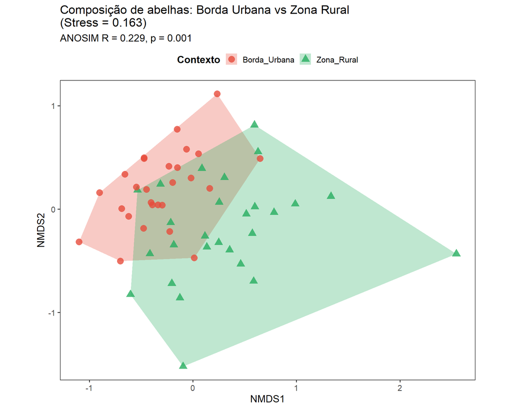

Figura 1: Composição de abelhas em bordas urbanas vs zonas rurais

```r
hull_contexto <- nmds_scores %>%
  group_by(contexto) %>%
  slice(chull(NMDS1, NMDS2))

ggplot() +
  geom_polygon(data = hull_contexto,
               aes(x = NMDS1, y = NMDS2, fill = contexto, group = contexto),
               alpha = 0.3) +
  geom_point(data = nmds_scores,
             aes(x = NMDS1, y = NMDS2, color = contexto, shape = contexto),
             size = 4, alpha = 0.8) +
  scale_fill_manual(values = c("Borda_Urbana" = "#E74C3C", "Zona_Rural" = "#27AE60")) +
  scale_color_manual(values = c("Borda_Urbana" = "#E74C3C", "Zona_Rural" = "#27AE60")) +
  coord_equal() +
  theme_bw(base_size = 14) +
  theme(
    legend.position = "top",
    legend.title = element_text(face = "bold"),
    panel.grid = element_blank()
  ) +
  labs(
    x = "NMDS1", y = "NMDS2",
    title = paste0("Composição de abelhas: Borda Urbana vs Zona Rural\n(Stress = ",
                   round(nmds_pontos$stress, 3), ")"),
    subtitle = paste0("ANOSIM R = ", round(anosim_contexto$statistic, 3),
                      ", p = ", anosim_contexto$signif),
    color = "Contexto", fill = "Contexto", shape = "Contexto"
  )
```

## 5.3 NMDS por Local

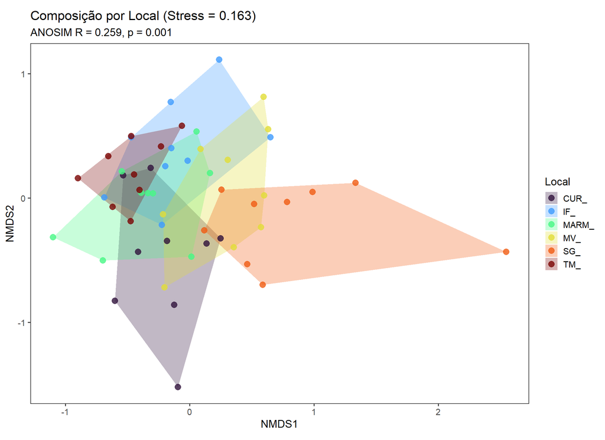

Figura 2: Composição de abelhas por local de amostragem

```r
hull_local <- nmds_scores %>%
  group_by(Local) %>%
  slice(chull(NMDS1, NMDS2))

ggplot() +
  geom_polygon(data = hull_local,
               aes(x = NMDS1, y = NMDS2, fill = Local, group = Local),
               alpha = 0.3) +
  geom_point(data = nmds_scores,
             aes(x = NMDS1, y = NMDS2, color = Local),
             size = 3.5, alpha = 0.8) +
  scale_fill_viridis_d(option = "turbo") +
  scale_color_viridis_d(option = "turbo") +
  coord_equal() +
  theme_bw(base_size = 14) +
  theme(legend.position = "right", panel.grid = element_blank()) +
  labs(
    x = "NMDS1", y = "NMDS2",
    title = paste0("Composição por Local (Stress = ", round(nmds_pontos$stress, 3), ")"),
    subtitle = paste0("ANOSIM R = ", round(anosim_local$statistic, 3),
                      ", p = ", anosim_local$signif)
  )
```

## 5.4 Gradiente de Habitat Natural

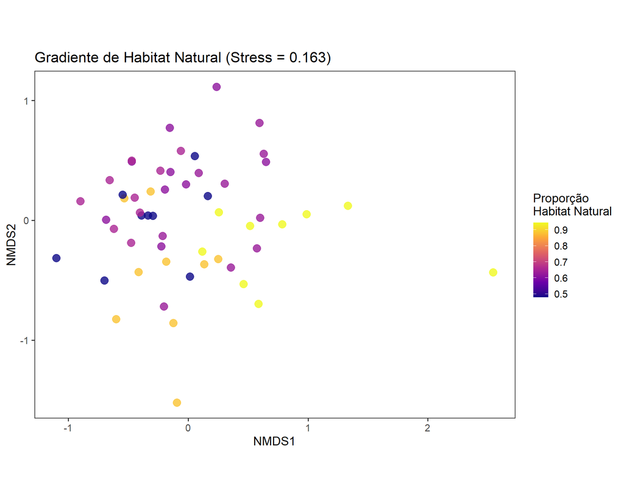

Figura 3: Gradiente de proporção de habitat natural

```r
ggplot(nmds_scores, aes(x = NMDS1, y = NMDS2, color = prop_hab_natural)) +
  geom_point(size = 4, alpha = 0.8) +
  scale_color_viridis_c(name = "Proporção\nHabitat Natural", option = "plasma") +
  coord_equal() +
  theme_bw(base_size = 14) +
  theme(panel.grid = element_blank()) +
  labs(
    x = "NMDS1", y = "NMDS2",
    title = paste0("Gradiente de Habitat Natural (Stress = ", round(nmds_pontos$stress, 3), ")")
  )
```

## 5.5 Vetores Ambientais (ENVFIT)

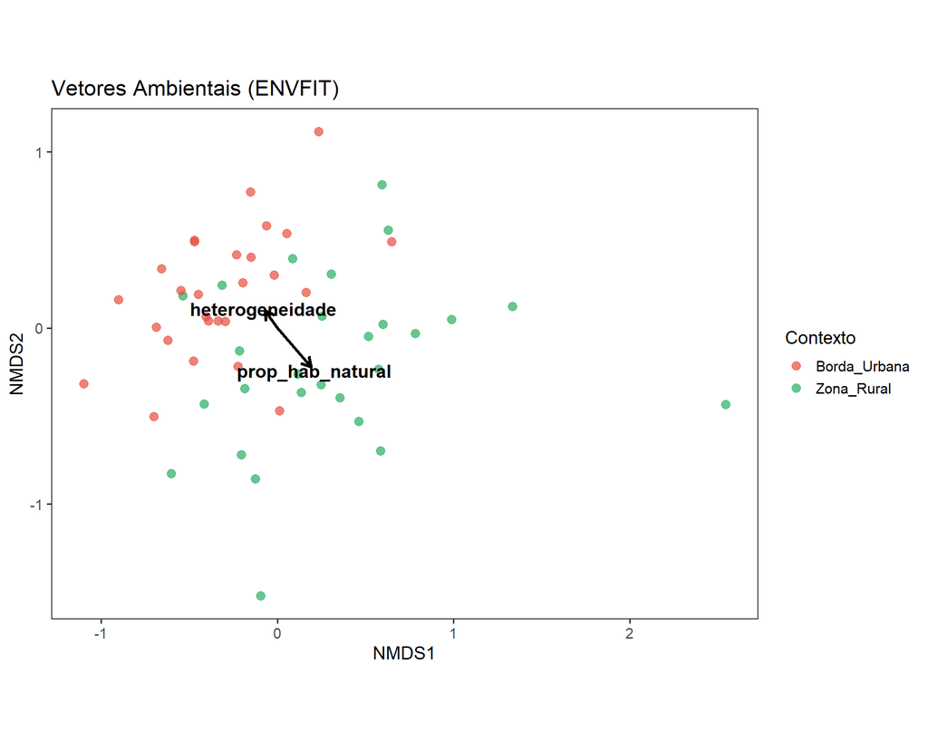

Figura 4: Vetores ambientais correlacionados com a ordenação

```r
envfit_coords <- as.data.frame(scores(envfit_resultado, "vectors")) * 0.5

ggplot() +
  geom_point(data = nmds_scores,
             aes(x = NMDS1, y = NMDS2, color = contexto),
             size = 3, alpha = 0.7) +
  geom_segment(data = envfit_coords,
               aes(x = 0, y = 0, xend = NMDS1, yend = NMDS2),
               arrow = arrow(length = unit(0.3, "cm")),
               color = "black", size = 1.2) +
  geom_text(data = envfit_coords,
            aes(x = NMDS1 * 1.1, y = NMDS2 * 1.1, label = rownames(envfit_coords)),
            size = 5, fontface = "bold") +
  scale_color_manual(values = c("Borda_Urbana" = "#E74C3C", "Zona_Rural" = "#27AE60")) +
  coord_equal() +
  theme_bw(base_size = 14) +
  theme(panel.grid = element_blank()) +
  labs(x = "NMDS1", y = "NMDS2", title = "Vetores Ambientais (ENVFIT)", color = "Contexto")
```

## 5.6 ANOSIM Pairwise

[figure not shown]

Figura 5: Comparações par-a-par entre locais

```r
ggplot(resultados_pairwise,
       aes(x = reorder(Comparacao, R_statistic), y = R_statistic,
           fill = p_adjusted < 0.05)) +
  geom_col() +
  geom_hline(yintercept = 0.5, linetype = "dashed", color = "red", size = 1) +
  scale_fill_manual(
    values = c("TRUE" = "#27AE60", "FALSE" = "gray70"),
    labels = c("p < 0.05", "p ≥ 0.05"),
    name = "Significância"
  ) +
  coord_flip() +
  theme_bw(base_size = 12) +
  labs(
    x = "Comparação entre Locais",
    y = "ANOSIM R statistic",
    title = "Diferenciação Par-a-Par entre Locais",
    subtitle = "Linha tracejada: R = 0.5 (diferença forte)"
  )
```

## 5.7 Riqueza vs Habitat Natural

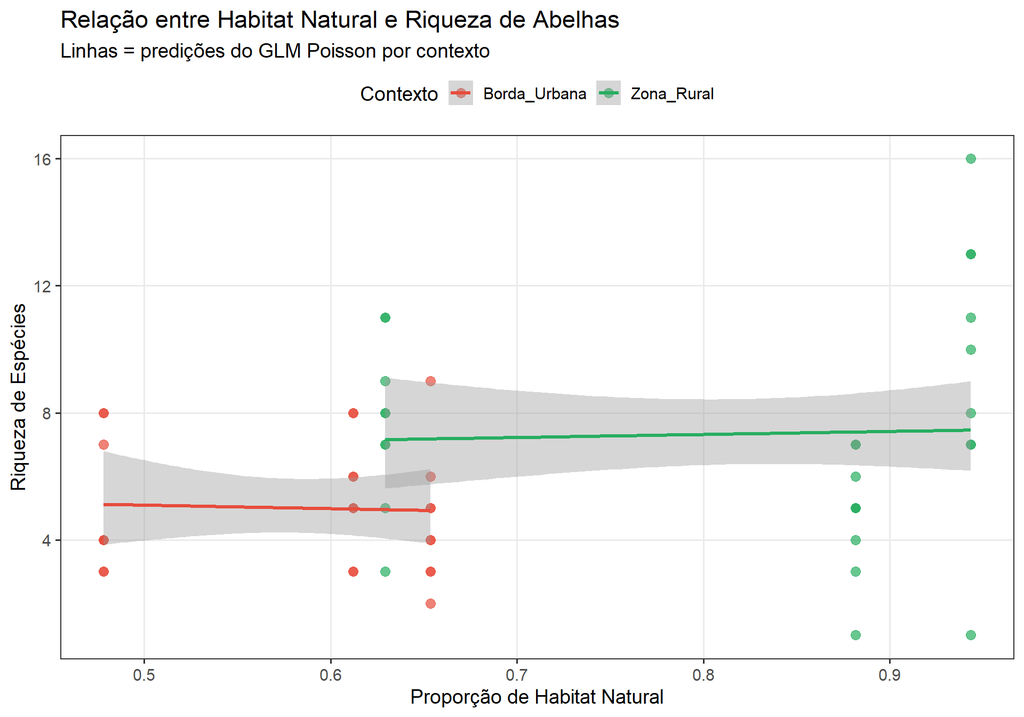

Figura 6: Relação entre riqueza e proporção de habitat natural

```r
ggplot(riqueza_por_ponto, aes(x = prop_hab_natural, y = riqueza, color = contexto)) +
  geom_point(size = 3, alpha = 0.7) +
  geom_smooth(method = "glm", method.args = list(family = "poisson"),
              se = TRUE, linewidth = 1.2) +
  scale_color_manual(values = c("Borda_Urbana" = "#E74C3C", "Zona_Rural" = "#27AE60"),
                     name = "Contexto") +
  theme_bw(base_size = 14) +
  theme(
    legend.position = "top",
    panel.grid.minor = element_blank()
  ) +
  labs(
    x = "Proporção de Habitat Natural",
    y = "Riqueza de Espécies",
    title = "Relação entre Habitat Natural e Riqueza de Abelhas",
    subtitle = "Linhas = predições do GLM Poisson por contexto"
  )
```

# 6 Tabela Resumo

```r
resumo_analises <- data.frame(
  Analise = c(
    "GLMM - Melhor modelo",
    "PERMANOVA - Habitat + Heterog",
    "PERMANOVA - + Contexto",
    "PERMANOVA - Interação",
    "PERMANOVA - Bloqueada",
    "ANOSIM - Borda vs Rural",
    "ANOSIM - Entre Locais",
    "ANOSIM - Categoria Habitat",
    "ENVFIT - Habitat Natural",
    "ENVFIT - Heterogeneidade"
  ),
  Estatistica = c(
    paste0("AICc = ", round(AICc(melhor_modelo), 1)),
    paste0("R² = ", round(perm1$R2[1], 3)),
    paste0("R² = ", round(perm2$R2[1], 3)),
    paste0("R² = ", round(perm3$R2[1], 3)),
    paste0("R² = ", round(perm_blocked$R2[1], 3)),
    paste0("R = ", round(anosim_contexto$statistic, 3)),
    paste0("R = ", round(anosim_local$statistic, 3)),
    paste0("R = ", round(anosim_habitat$statistic, 3)),
    paste0("r² = ", round(envfit_resultado$vectors$r[1], 3)),
    paste0("r² = ", round(envfit_resultado$vectors$r[2], 3))
  ),
  p_value = c(
    ifelse(length(fixef(melhor_modelo)) > 2,
           round(summary(melhor_modelo)$coefficients[2, 4], 4),
           "—"),
    round(perm1$`Pr(>F)`[1], 4),
    round(perm2$`Pr(>F)`[1], 4),
    round(perm3$`Pr(>F)`[1], 4),
    round(perm_blocked$`Pr(>F)`[1], 4),
    round(anosim_contexto$signif, 4),
    round(anosim_local$signif, 4),
    round(anosim_habitat$signif, 4),
    round(envfit_resultado$vectors$pvals[1], 4),
    round(envfit_resultado$vectors$pvals[2], 4)
  )
)

resumo_analises
```

| Analise | Estatistica | p_value |
| --- | --- | --- |
| GLMM - Melhor modelo | AICc = 264 | 0.0003 |
| PERMANOVA - Habitat + Heterog | R² = 0.15 | 0.0010 |
| PERMANOVA - + Contexto | R² = 0.187 | 0.0010 |
| PERMANOVA - Interação | R² = 0.277 | 0.0010 |
| PERMANOVA - Bloqueada | R² = 0.15 | 1.0000 |
| ANOSIM - Borda vs Rural | R = 0.229 | 0.0010 |
| ANOSIM - Entre Locais | R = 0.259 | 0.0010 |
| ANOSIM - Categoria Habitat | R = 0.192 | 0.0010 |
| ENVFIT - Habitat Natural | r² = 0.342 | 0.0010 |
| ENVFIT - Heterogeneidade | r² = 0.059 | 0.1930 |

# 7 Conclusões

## 7.1 Principais Resultados

Este documento apresentou uma análise completa das comunidades de abelhas do Cerrado, incluindo:

### 7.1.1 1. Diversidade Alfa (GLMM)

- Utilizamos **modelos mistos** (GLMM) com os **54 pontos**, controlando a pseudorreplicação através do efeito aleatório de Local
- Esta abordagem é **estatisticamente mais robusta** do que usar apenas os 6 locais como unidades independentes
- O melhor modelo (menor AICc) foi selecionado através de comparação entre modelos candidatos

## 7.3 Arquivos Gerados

Este script gera automaticamente:

- ✅ 6 figuras de alta qualidade (incorporadas neste relatório)
- ✅ Este relatório HTML completo e reproduzível
- ✅ Todas as análises estatísticas necessárias

# 8 Informações da Sessão

**Análise realizada em:** 22/10/2025

*Documento gerado com R Markdown*